# Clustering: wheat varieties

Choosing the number of clusters when the criteria disagree, and judging a partition by compactness, by stability, and against a known truth – three rankings that need not agree.

The other vignettes are listed by `vignette (package = "fdm2id")`; they use the same handful of functions on other data, and can be read in any order.

```r
library (fdm2id)
```

# The data

Three varieties of wheat grain – Kama, Rosa and Canadian – with 70 observations of each, studied by X-ray. Seven geometric descriptors were extracted: area, perimeter, compactness, length, width, asymmetry coefficient and length of the groove. The eighth column is the variety, which is *not* used to build the clusters – only to judge them at the very end.

```r
data (wheat)
summary (wheat [, -8])
```

```
#>       Area         Perimeter      Compactness         Length
#>  Min.   :10.59   Min.   :12.41   Min.   :0.8081   Min.   :4.899
#>  1st Qu.:12.27   1st Qu.:13.45   1st Qu.:0.8569   1st Qu.:5.262
#>  Median :14.36   Median :14.32   Median :0.8734   Median :5.524
#>  Mean   :14.85   Mean   :14.56   Mean   :0.8710   Mean   :5.629
#>  3rd Qu.:17.30   3rd Qu.:15.71   3rd Qu.:0.8878   3rd Qu.:5.980
#>  Max.   :21.18   Max.   :17.25   Max.   :0.9183   Max.   :6.675
#>      Width         Asymmetry          Groove
#>  Min.   :2.630   Min.   :0.7651   Min.   :4.519
#>  1st Qu.:2.944   1st Qu.:2.5615   1st Qu.:5.045
#>  Median :3.237   Median :3.5990   Median :5.223
#>  Mean   :3.259   Mean   :3.7002   Mean   :5.408
#>  3rd Qu.:3.562   3rd Qu.:4.7687   3rd Qu.:5.877
#>  Max.   :4.033   Max.   :8.4560   Max.   :6.550
```

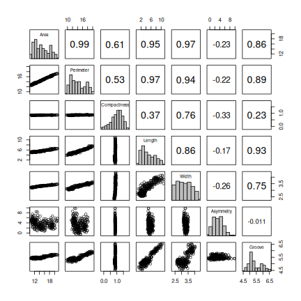

```r
plotdata (wheat [, -8])
```

# Question 1. Raw data, or centred and scaled?

```r
apply (wheat [, -8], 2, sd)
```

```
#>        Area   Perimeter Compactness      Length       Width   Asymmetry
#>  2.90969943  1.30595873  0.02362942  0.44306348  0.37771444  1.50355713
#>      Groove
#>  0.49148050
```

**Answer.** *The variables are expressed in different units, and their standard deviations are nowhere near homogeneous – `Area` weighs a hundred times more than `Compactness` in a Euclidean distance. Better to work on the centred and scaled data.*

```r
wheat [, -8] = scale (wheat [, -8])
```

# Question 2. How many clusters do the methods see?

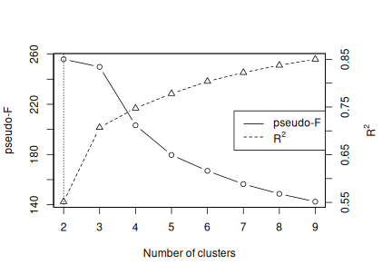

```
#> [1] 2
```

```r
# Variable: K-means starts from centres drawn at random. 'nstart = 100' keeps the best of a
# hundred starts, which makes the answer stable in practice, but only 'seed' makes it exact.
kmeans.getk (wheat [, -8], nstart = 100, graph = TRUE, seed = 0)
```

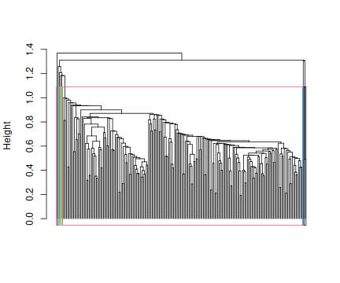

```r
single = HCA (wheat [, -8], method = "single")
plotclus (single, wheat, "tree")
```

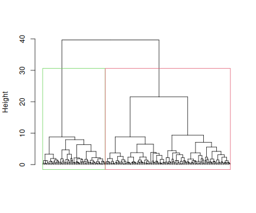

```r
ward = HCA (wheat [, -8], method = "ward")
plotclus (ward, wheat, "tree")
```

**Answer.**

- *For $K$-means: the pseudo-$F$ is highest at two clusters, but its value at three is high as well.*
- *For single linkage: no cluster can be read off the dendrogram at all – the chaining effect leaves a comb.*
- *For Ward: the largest jump splits the data in two, but a split in three also looks reasonable.*

Criteria disagree, and that disagreement is itself informative:

```r
sapply (c ("pseudo-F", "silhouette", "elbow"),
        function (criterion) kmeans.getk (wheat [, -8], criterion = criterion,
                                          nstart = 100, seed = 0))
```

```
#>   pseudo-F silhouette      elbow
#>          2          2          3
```

# Question 3. With three clusters, which method is the most compact? The most stable?

```r
km = KMEANS (wheat [, -8], k = 3, nstart = 100, seed = 0)
ward = HCA (wheat [, -8], k = 3, method = "ward")
intern (km, wheat [, -8], eval = c ("intraclass", "interclass"))
```

```
#> intraclass interclass
#>   428.6082  1034.3918
```

```r
intern (ward, wheat [, -8], eval = c ("intraclass", "interclass"))
```

```
#> intraclass interclass
#>   442.9298  1020.0702
```

```r
# Variable: stability resamples the dataset. Note that HCA itself is deterministic -- here the
# randomness is entirely in the resampling, not in the method being judged.
stability (KMEANS, wheat [, -8], type = "global", k = 3, nstart = 100, seed = 0)
```

```
#>   jaccard
#> 0.9335771
```

```r
stability (HCA, wheat [, -8], type = "global", method = "ward", k = 3, seed = 0)
```

```
#>   jaccard
#> 0.8400962
```

**Answer.** *$K$-means produces the more compact clusters – lower within-cluster inertia, higher between-cluster inertia – and the more stable ones, with a higher Jaccard index under resampling.*

# Question 4. Which method comes closest to the three varieties?

Comparing a clustering with a known truth is not the same problem as evaluating a classifier: the cluster numbers mean nothing, only the grouping does. `comp = "pairwise"` therefore counts pairs of observations rather than labels.

```r
compare (km, wheat [, 8], comp = "pairwise")
```

```
#>  accuracy
#> 0.8997038
```

```r
compare (ward, wheat [, 8], comp = "pairwise")
```

```
#>  accuracy
#> 0.9101846
```

**Answer.** *Ward’s clusters are very slightly closer to the three varieties than $K$-means’.*

Note that this reverses the ranking of question 3: the more compact and more stable clustering is not the one that recovers the varieties best. Compactness and stability are properties of the partition on its own, and can be computed without ever knowing the varieties; agreement measures the partition against something outside the data it was built from. Nothing guarantees that the two rankings agree, and here they do not.

```r
table (km$cluster, wheat [, 8])
```

```
#>
#>     Kama Rosa Canadian
#>   1    2   65        0
#>   2   62    5        4
#>   3    6    0       66
```

```r
table (ward$cluster, wheat [, 8])
```

```
#>
#>     Kama Rosa Canadian
#>   1   64    4        5
#>   2    4   66        0
#>   3    2    0       65
```

Both partitions line up with the three varieties, and both make their mistakes in the same place: almost every misassigned grain involves Kama, the variety that sits geometrically between the other two.